# Project Python Foundations: FoodHub Data Analysis

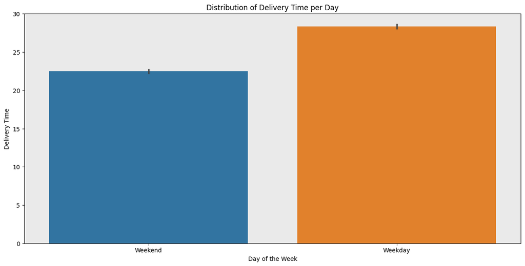

```python
plt.figure(figsize=(15, 7))
ax = sns.barplot(data=df, x='day_of_the_week', y='delivery_time', hue = 'day_of_the_week')
plt.title('Distribution of Delivery Time per Day')
plt.ylabel('Delivery Time')
plt.xlabel('Day of the Week')
ax.set_facecolor('#eaeaea')
plt.show()
```

Day of the week vs Cost of the order

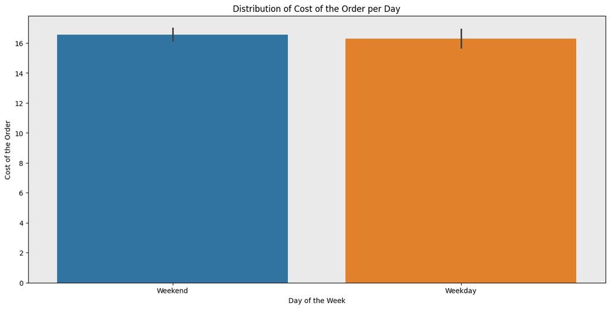

```python
plt.figure(figsize=(15, 7))
ax = sns.barplot(data=df, x='day_of_the_week', y='cost_of_the_order', hue = 'day_of_the_week')
plt.title('Distribution of Cost of the Order per Day')
plt.ylabel('Cost of the Order')
plt.xlabel('Day of the Week')
ax.set_facecolor('#eaeaea')
plt.show()
```

Food Preparation time vs Day of the week

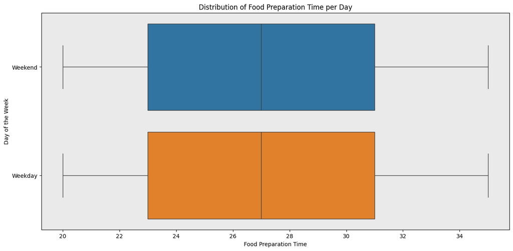

```python
plt.figure(figsize=(15, 7))
ax = sns.boxplot(data=df, x='food_preparation_time', y='day_of_the_week', hue = 'day_of_the_week', order = df['day_of_the_week'].value_counts().index)
plt.title('Distribution of Food Preparation Time per Day')
plt.ylabel('Day of the Week')
plt.xlabel('Food Preparation Time')
ax.set_facecolor('#eaeaea')

plt.show()
```

Rating vs Delivery time

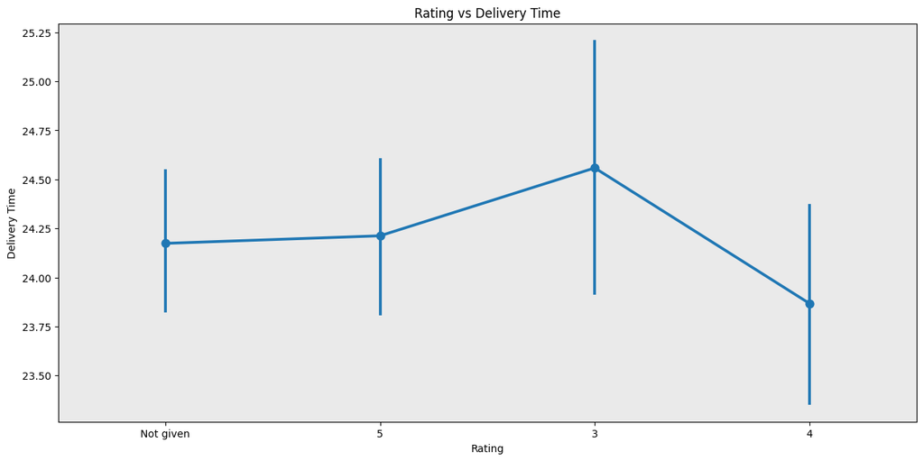

```python
plt.figure(figsize=(15, 7))
ax = sns.pointplot(data=df, x='rating', y='delivery_time')
plt.title('Rating vs Delivery Time')
plt.xlabel('Rating')
plt.ylabel('Delivery Time')
ax.set_facecolor('#eaeaea')
plt.show()
```

Rating vs Food Preparation time

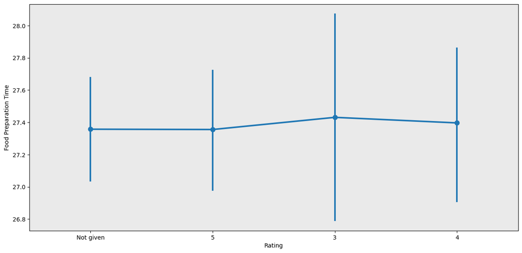

```python
plt.figure(figsize=(15, 7))
ax = sns.pointplot(data=df, x='rating', y='food_preparation_time')
plt.xlabel('Rating')
plt.ylabel('Food Preparation Time')
ax.set_facecolor('#eaeaea')
plt.show()
```

Rating vs Cost of the order

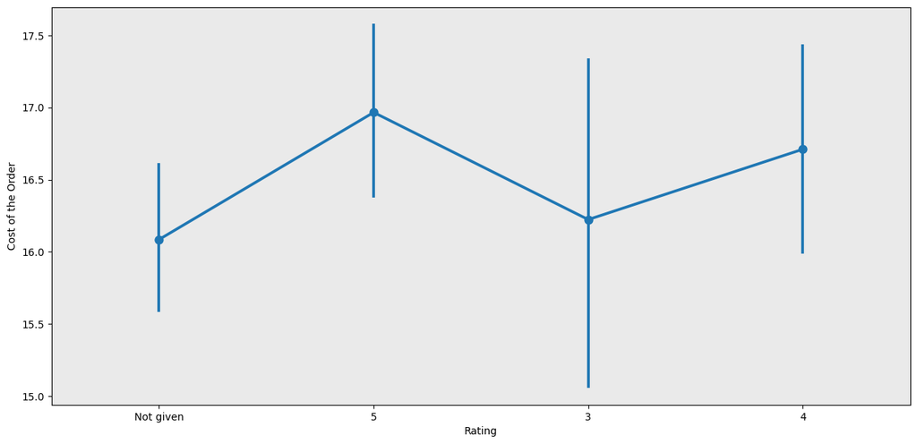

```python
plt.figure(figsize=(15, 7))
ax = sns.pointplot(data=df, x='rating', y='cost_of_the_order')
plt.xlabel('Rating')
plt.ylabel('Cost of the Order')
ax.set_facecolor('#eaeaea')
plt.show()
```

Numerical Variable Relationship Pairplot

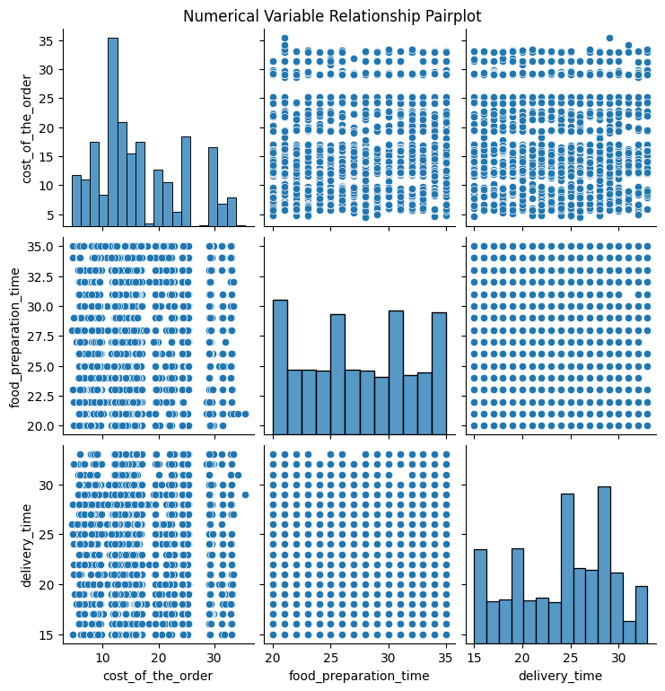

```python
plt.figure(figsize=(15, 7))
ax = sns.pairplot(data = df[['cost_of_the_order','food_preparation_time','delivery_time']])
ax.fig.suptitle("Numerical Variable Relationship Pairplot", y=1.02)
ax.fig.subplots_adjust(top=.99)
plt.show()
```

Variable Heatmap

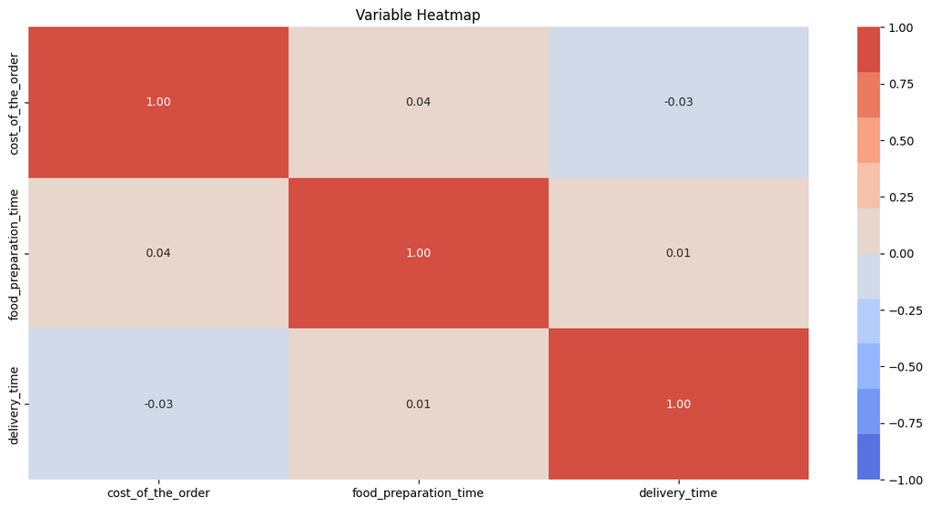

```python
plt.figure(figsize=(15, 7))
ax = sns.heatmap(df[['cost_of_the_order','food_preparation_time','delivery_time']].corr(), annot=True,vmin=-1, vmax=1, fmt='.2f', cmap = sns.color_palette('coolwarm', 10))
ax.set_title('Variable Heatmap')
plt.show()
```

### **Question 13:** The company wants to provide a promotional offer in the advertisement of the restaurants. The condition to get the offer is that the restaurants must have a rating count of more than 50 and the average rating should be greater than 4. Find the restaurants fulfilling the criteria to get the promotional offer. [3 marks]

```python
df_rated = df[df['rating'] != 'Not given'].copy()
df_rated['rating'] = df_rated['rating'].astype('int')
df_sorted = df_rated.groupby(by = ['restaurant_name']).agg(count = ('rating', 'size'), mean = ('rating', 'mean')).loc[lambda agg: (agg['count'] > 50) & (agg['mean'] > 4)].sort_values(by = 'mean', ascending = False).reset_index()
df_sorted.head()
```

|  | restaurant_name | count | mean |
| --- | --- | --- | --- |
| 0 | The Meatball Shop | 84 | 4.511905 |
| 1 | Blue Ribbon Fried Chicken | 64 | 4.328125 |
| 2 | Shake Shack | 133 | 4.278195 |
| 3 | Blue Ribbon Sushi | 73 | 4.219178 |

#### Observations: The restaurants that fill this criteria are The Meatball Shop, Blue Ribbon Fried Chicken, Shake Shake, and Blue Ribbon Sushi

### **Question 14:** The company charges the restaurant 25% on the orders having cost greater than 20 dollars and 15% on the orders having cost greater than 5 dollars. Find the net revenue generated by the company across all orders. [3 marks]

```python
def generate_revenue(cost):
    if cost > 20: return cost * 0.25
    elif cost > 5: return cost * 0.15
    else: return 0

df['revenue'] = df['cost_of_the_order'].apply(generate_revenue)
print(f"Net Revenue: ${df['revenue'].sum():.2f}")
```

```
Net Revenue: $6166.30
```

#### Observations: The net revenue generated by the company across all orders is $6166.30.

### **Question 15:** The company wants to analyze the total time required to deliver the food. What percentage of orders take more than 60 minutes to get delivered from the time the order is placed? (The food has to be prepared and then delivered.) [2 marks]

```python
total_time = df['food_preparation_time'] + df['delivery_time']
percentage = total_time[total_time > 60].shape[0] / total_time.shape[0] * 100
print(f"Percentage of orders that longer than 60 minutes to get delivered: {percentage:.2f}%")
```

```
Percentage of orders that longer than 60 minutes to get delivered: 10.54%
```

#### Observations: The percentage of orders take more than 60 minutes to get delivered from the time the order is placed is 10.54%.

### **Question 16:** The company wants to analyze the delivery time of the orders on weekdays and weekends. How does the mean delivery time vary during weekdays and weekends? [2 marks]

```python
print(f"The mean delivery time on the weekday is {df[df['day_of_the_week'] == 'Weekday']['delivery_time'].mean():.2f}%.")
print(f"The mean delivery time on the weekend is {df[df['day_of_the_week'] == 'Weekend']['delivery_time'].mean():.2f}%.")
```

```
The mean delivery time on the weekday is 28.34%.
The mean delivery time on the weekend is 22.47%.
```